# Statistical Inference - Course project 2 (Author: Peter)

## Part II

In the second part I will analyze the ToothGrowth data set that comes with the R `datasets` package, performing some basic exploratory analysis, data summary and using confidence intervals for further statistical analysis.

### Preliminaries

Let us first of all load packages and data.

```r
library(ggplot2)
library(gridExtra)
library(datasets)
# now load data
data("ToothGrowth")
tooths = ToothGrowth
tooths$dose = as.factor(tooths$dose)
```

### Basic summary and exploratory analysis of the data

As often, we simply start out with printing out some information about the data, the ones given by `str`, `summary`, and a simple boxplot.

```r
str(tooths)
```

```
## 'data.frame':    60 obs. of  3 variables:
##  $ len : num  4.2 11.5 7.3 5.8 6.4 10 11.2 11.2 5.2 7 ...
##  $ supp: Factor w/ 2 levels "OJ","VC": 2 2 2 2 2 2 2 2 2 2 ...
##  $ dose: Factor w/ 3 levels "0.5","1","2": 1 1 1 1 1 1 1 1 1 1 ...
```

```r
summary(tooths)
```

```
##       len        supp     dose
##  Min.   : 4.20   OJ:30   0.5:20
##  1st Qu.:13.07   VC:30   1  :20
##  Median :19.25           2  :20
##  Mean   :18.81
##  3rd Qu.:25.27
##  Max.   :33.90
```

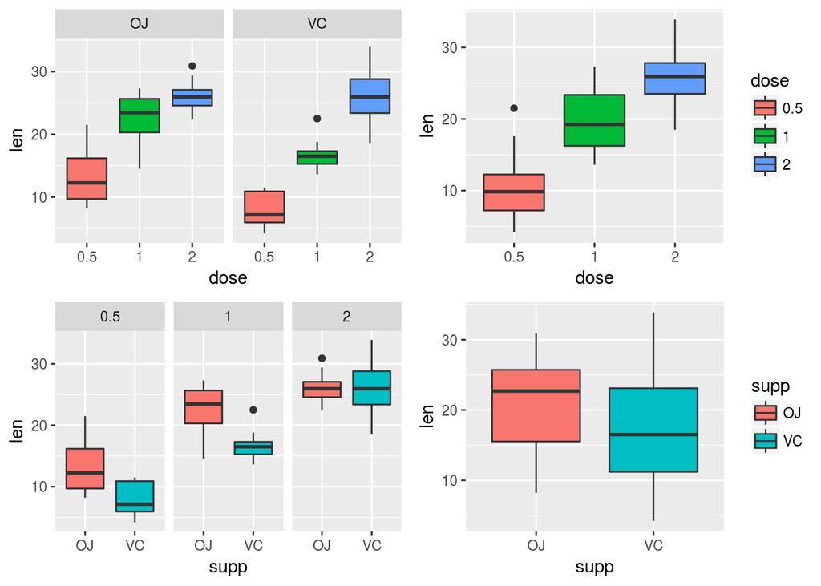

```r
p1 <- ggplot(data=tooths, aes(x=dose,y=len,fill=dose)) +
  geom_boxplot() +
  theme(legend.position="none") +
  facet_grid(.~supp)

p2 <- ggplot(data=tooths, aes(x=supp,y=len,fill=supp)) +
  geom_boxplot() +
  theme(legend.position="none") +
  facet_grid(.~dose)

p3 <- ggplot(data=tooths, aes(x=supp,y=len,fill=supp)) +
  geom_boxplot()

p4 <- ggplot(data=tooths, aes(x=dose,y=len,fill=dose)) +
  geom_boxplot()

grid.arrange(p1, p4, p2, p3, ncol = 2, nrow=2)
```

### Hypothesis tests with confidence intervals

Let’s start with the “null” hypothesis that there is no correlation between the `delivery method` and the `tooth length`, and let’s analyze possible correlation between the two.

```r
t.test(len ~ supp, paired=FALSE, var.equal=FALSE, data=tooths)
```

```
##
##  Welch Two Sample t-test
##
## data:  len by supp
## t = 1.9153, df = 55.309, p-value = 0.06063
## alternative hypothesis: true difference in means is not equal to 0
## 95 percent confidence interval:
##  -0.1710156  7.5710156
## sample estimates:
## mean in group OJ mean in group VC
##         20.66333         16.96333
```

The test tells us the 95% confidence interval is $[-0.1710156, 7.5710156]$, which contains the zero value. Furthermore, the p-value is 0.06 that is larger than 0.05, therefore we cannot reject the null hypothesis.

Let’s double check this result with the analysis of variance (ANOVA):

```r
anovaRes = aov(len ~ supp*dose, data=tooths)
summary(anovaRes)
```

```
##             Df Sum Sq Mean Sq F value   Pr(>F)
## supp         1  205.4   205.4  15.572 0.000231 ***
## dose         2 2426.4  1213.2  92.000  < 2e-16 ***
## supp:dose    2  108.3    54.2   4.107 0.021860 *
## Residuals   54  712.1    13.2
## ---
## Signif. codes:  0 '***' 0.001 '**' 0.01 '*' 0.05 '.' 0.1 ' ' 1
```

## Conclusions

It is worth noticing that these results are valid under the following assumptions:

- The sampled data are representative of the population (of the guinea pigs)
- Dosage and Supplement were randomly distributed in the population
- The means’ distribution is normal.